# Number of In-Person versus Online Interactions in Daily Life During COVID-19 ~ Close Out-Degree

Ovidia Stanoi

2025-02-26

### Prepare data for regression analyses.

Remove all data from the global environment.

```r
remove(list=ls())
```

Load libraries.

```r
library("tidyverse")
library("rstanarm")
library("sjPlot")
library("brms")
library("ggpubr")
```

Specify your directory path below.

```r
path <- ""
```

Open dataset.

```r
covid_ema <- read.csv(sprintf("%s/Data/all_data_merged_clean.csv", path))
```

See the distribution of the two outcome variables: number of in-person and online interactions.

##### Number of In-Person Interactions

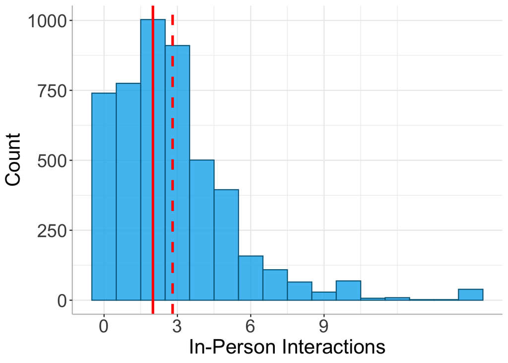

```r
g1 <- ggplot(covid_ema, aes(PhysInt_NUM)) +
  geom_histogram(fill = "deepskyblue2", color = "deepskyblue4",
                 alpha = .8, binwidth = 1) +
  labs(x = "In-Person Interactions",
       y = "Count") +
  geom_vline(xintercept = median(covid_ema$PhysInt_NUM, na.rm = T),
             color = "red", linewidth = 1.2) +
  geom_vline(xintercept = mean(covid_ema$PhysInt_NUM, na.rm = T),
             color = "red", linewidth = 1.2, linetype = "dashed") +
  scale_x_continuous(breaks=seq(0,9,3))+
  theme_bw() +
  theme(axis.text=element_text(size=18),
        plot.title = element_text(size=22, hjust = .5),
        axis.title=element_text(size=20),
        axis.line = element_line(colour = "gray"),
        panel.border = element_blank())
g1
```

##### Number of Online Interactions

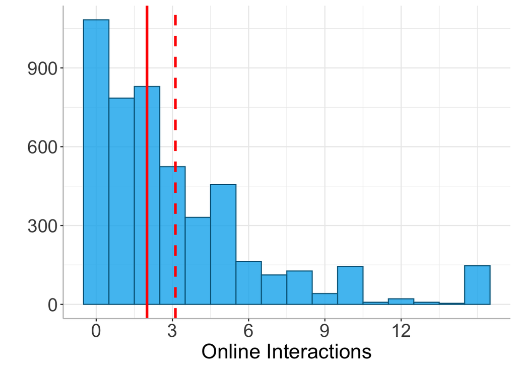

```r
g2 <- ggplot(covid_ema, aes(SocInt_NUM)) +
  geom_histogram(fill = "deepskyblue2", color = "deepskyblue4",
                 alpha = .8, binwidth = 1) +
  labs(x = "Online Interactions",
       y = "") +
  geom_vline(xintercept = median(covid_ema$SocInt_NUM, na.rm = T),
             color = "red", linewidth = 1.2) +
  geom_vline(xintercept = mean(covid_ema$SocInt_NUM, na.rm = T),
             color = "red", linewidth = 1.2, linetype = "dashed") +
  scale_x_continuous(breaks=seq(0,12,3))+
  theme_bw() +
  theme(axis.text=element_text(size=18),
        plot.title = element_text(size=22, hjust = .5),
        axis.title=element_text(size=20),
        axis.line = element_line(colour = "gray"),
        panel.border = element_blank())
g2
```

Save both figures in one figure with two panels.

```r
g <- ggarrange(g1, g2, ncol = 2,
               labels = c("A.","B."))
ggsave(file=sprintf("%s/Figures/2.a.Nr-InPerson-Online-Interactions_Histogram-Plots.pdf",
                    path), g, units="in", width=12, height=7, dpi=300)
```

Run Kolmogorov-Smirnov test to check whether variable representing the number of in-person interactions is normally distributed.

```r
t_inperson <- ks.test(covid_ema$PhysInt_NUM, "pnorm")
t_inperson
```

```
##
##  Asymptotic one-sample Kolmogorov-Smirnov test
##
## data:  covid_ema$PhysInt_NUM
## D = 0.68759, p-value < 2.2e-16
## alternative hypothesis: two-sided
```

Run Kolmogorov-Smirnov test to check whether variable representing the number of online interactions is normally distributed.

```r
t_online <- ks.test(covid_ema$SocInt_NUM, "pnorm")
t_online
```

```
##
##  Asymptotic one-sample Kolmogorov-Smirnov test
##
## data:  covid_ema$SocInt_NUM
## D = 0.61492, p-value < 2.2e-16
## alternative hypothesis: two-sided
```

Extract for each participant their median number of in-person and online interactions during the EMA period, as well as their number of close friend prior to the COVID-19 pandemic, their baseline demographic information, COVID-19 living conditions, number of stressors, and EMA completion rates. All these variables will be added in the regression model.

```r
df <- covid_ema %>%
  group_by(pID) %>%
  dplyr::summarise(groupID = unique(groupID),
                   median_PhysInt_NUM = median(PhysInt_NUM, na.rm = T),
                   median_SocInt_NUM = median(SocInt_NUM, na.rm = T),
                   baseline_closest_deg_out_norm = unique(baseline_closest_deg_out_norm),
                   baseline_income_num = unique(baseline_income_num),
                   baseline_educ_parents_years = unique(baseline_educ_parents_years),
                   baseline_college_year = unique(baseline_college_year),
                   baseline_gender_numeric = unique(baseline_gender_numeric),
                   covid_housing_tension = unique(covid_housing_tension),
                   covid_phys_dist = unique(covid_phys_dist_avg),
                   EMA_completion_rate = unique(EMA_completion_rate))
```

Center continuous predictors around the sample mean and binary variables around zero.

```r
df$baseline_closest_deg_out_norm_c <- df$baseline_closest_deg_out_norm - mean(df$baseline_closest_deg_out_norm, na.rm = T)
df$baseline_income_num_c <- df$baseline_income_num - mean(df$baseline_income_num, na.rm = T)
df$baseline_educ_parents_years_c <- df$baseline_educ_parents_years - mean(df$baseline_educ_parents_years, na.rm = T)
df$baseline_college_year_c <- df$baseline_college_year - mean(df$baseline_college_year, na.rm = T)
df$baseline_gender_numeric_c <- df$baseline_gender_numeric - .5
df$covid_housing_tension_c <- df$covid_housing_tension - mean(df$covid_housing_tension, na.rm = T)
df$covid_phys_dist_c  <- df$covid_phys_dist - mean(df$covid_phys_dist, na.rm = T)
df$EMA_completion_rate_c  <- df$EMA_completion_rate - mean(df$EMA_completion_rate, na.rm = T)
```

### Run regression models

##### Model 1: Outcome Variable = Median Number of In-Person Interactions

**RQ**: Do people with more close friends in college have more interactions in-person on a typical day during the COVID-19 pandemic?

Run regression analysis 1: median number of in-person interactions ~ close out-degree.

```r
options(mc.cores = parallel::detectCores())
fa <- stan_glmer(median_PhysInt_NUM ~ baseline_closest_deg_out_norm_c +
                   baseline_income_num_c + baseline_educ_parents_years_c + baseline_college_year_c +
                   baseline_gender_numeric_c + covid_housing_tension_c + covid_phys_dist_c +
                   EMA_completion_rate_c + (1 | groupID),
                 data = df, seed = 123)
save(fa, file = sprintf("%s/Models/2.a.Nr-InPerson_Interactions_Out-Degree.RData", path))
```

##### Model 2: Outcome Variable = Median Number of Online Interactions

**RQ**: Do people with more close friends in college have more online interactions on a typical day during the COVID-19 pandemic?

Run regression analysis 1: median number of online interactions ~ close out-degree.

```r
options(mc.cores = parallel::detectCores())
fb <- stan_glmer(median_SocInt_NUM ~ baseline_closest_deg_out_norm_c +
                   baseline_income_num_c + baseline_educ_parents_years_c + baseline_college_year_c +
                   baseline_gender_numeric_c + covid_housing_tension_c + covid_phys_dist_c +
                   EMA_completion_rate_c + (1 | groupID),
                 data = df, seed = 123)
save(fb, file = sprintf("%s/Models/2.a.Nr-Online_Interactions_Out-Degree.RData", path))
```

### Summarize results

Create a table that presents the parameter estimates from the two models together.

```r
tab_model(fa, fb, show.se = TRUE,
          show.r2 = TRUE,
          dv.labels = c("Median Number of In-Person Interactions",
                        "Median Number of Online Interactions"),
          pred.labels = c("(Intercept)",
                          "Close Out-Degree Prior to COVID19",
                          "HH Income",
                          "Parents' Education",
                          "Year in College",
                          "Female",
                          "HH Tension",
                          "Physical Distance",
                          "EMA Completion Rate"),
          file = sprintf("%s/Tables/2.a. Nr-InPerson-Online_Interactions_Out-Degree.html", path))
```

|  | Median Number of In-Person Interactions |  |  | Median Number of Online Interactions |  |  |
| --- | --- | --- | --- | --- | --- | --- |
| Predictors | Estimates | std. Error | CI (95%) | Estimates | std. Error | CI (95%) |
| (Intercept) | 2.45 | 0.14 | 2.18 – 2.72 | 2.67 | 0.24 | 2.21 – 3.15 |
| Close Out-Degree Prior to COVID19 | -0.00 | 0.01 | -0.02 – 0.02 | 0.02 | 0.02 | -0.02 – 0.06 |
| HH Income | 0.01 | 0.02 | -0.03 – 0.06 | -0.03 | 0.04 | -0.11 – 0.04 |
| Parents’ Education | 0.05 | 0.03 | -0.01 – 0.11 | 0.03 | 0.05 | -0.07 – 0.13 |
| Year in College | 0.01 | 0.10 | -0.18 – 0.21 | 0.14 | 0.17 | -0.18 – 0.47 |
| Female | 0.11 | 0.26 | -0.40 – 0.65 | 0.44 | 0.48 | -0.52 – 1.35 |
| HH Tension | 0.01 | 0.00 | -0.00 – 0.02 | 0.00 | 0.01 | -0.01 – 0.02 |
| Physical Distance | -0.09 | 0.15 | -0.41 – 0.21 | 0.51 | 0.28 | -0.02 – 1.05 |
| EMA Completion Rate | -0.17 | 0.80 | -1.69 – 1.39 | -1.20 | 1.41 | -3.96 – 1.51 |
| Random Effects |  |  |  |  |  |  |
| σ<sup>2</sup> | 2.51 |  |  | 7.28 |  |  |
| τ<sub>00</sub> | 0.07 <sub>groupID</sub> |  |  | 0.17 <sub>groupID</sub> |  |  |
| ICC | 0.03 |  |  | 0.02 |  |  |
| N | 24 <sub>groupID</sub> |  |  | 24 <sub>groupID</sub> |  |  |
| Observations | 205 |  |  | 205 |  |  |
| Marginal R<sup>2</sup> / Conditional R<sup>2</sup> | 0.050 / 0.075 |  |  | 0.036 / 0.058 |  |  |

Below, extract the proportion of the posterior distribution that is above or below zero for each predictor of interest separately for the two regression model (median number of in-person and online interactions).

##### Model 1: Outcome Variable = Median Number of In-Person Interactions

Extract the posterior distributions of the parameter estimates from the first regression model.

```r
posterior <- as.data.frame(as.matrix(fa))
```

Extract the number of individual points included in a posterior distribution.

```r
n <- length(posterior$baseline_closest_deg_out_norm_c)
n
```

```
## [1] 4000
```

Calculate the proportion of the posterior distribution that is higher than 0 for the main effect of close out-degree on the median number of in-person interactions.

```r
round(length(which(posterior$baseline_closest_deg_out_norm_c > 0))/n*100,1)
```

```
## [1] 47.7
```

Calculate the total $R^2$ for the model.

```r
round(mean(bayes_R2(fa)),2)
```

```
## [1] 0.1
```

##### Model 2: Outcome Variable = Median Number of Online Interactions

Extract the posterior distributions of the parameter estimates from the first regression model.

```r
posterior <- as.data.frame(as.matrix(fb))
```

Extract the number of individual points included in a posterior distribution.

```r
n <- length(posterior$baseline_closest_deg_out_norm_c)
n
```

```
## [1] 4000
```

Calculate the proportion of the posterior distribution that is higher than 0 for the main effect of close out-degree on the median number of online interactions.

```r
round(length(which(posterior$baseline_closest_deg_out_norm_c > 0))/n*100,1)
```

```
## [1] 80.2
```

Calculate the total $R^2$ for the model.

```r
round(mean(bayes_R2(fb)),2)
```

```
## [1] 0.09
```

### Plot results

##### Model 1: Outcome Variable = Median Number of In-Person Interactions

Create a scatterplot of the relationship between participants’ close out-degree and their median number of in-person interactions.

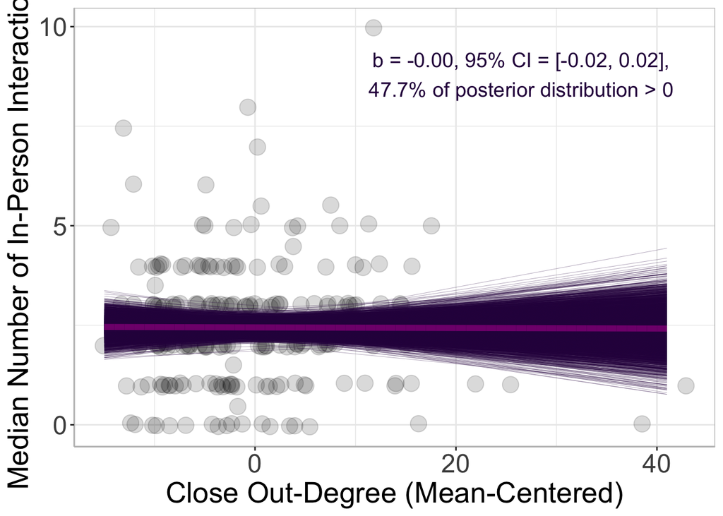

```r
# Extract all posterior distributions
p <- posterior_samples(fa)[, c(1:2)]
colnames(p) <- c("intercept", "baseline_closest_deg_out_norm_c")
p <- p %>%
  dplyr::mutate(draw = 1:4000,
                m_int = median(intercept), # Extract fixed effects medians from the model
                m_b_close_deg_out = median(baseline_closest_deg_out_norm_c))

# Define number of posterior draws
nr_random_draws <- 4000

# Add predicted y values for the random draws and fixed effects
p2 <- p[rep(seq_len(nrow(p)), each = 57), ] %>%
  mutate(seq = rep(-15:41, nr_random_draws)) %>%
  rowwise() %>%
  dplyr::mutate(y_draw = intercept + baseline_closest_deg_out_norm_c * seq,
                y_fe = m_int + m_b_close_deg_out * seq)

## Plot results
ggplot(data = df, aes(baseline_closest_deg_out_norm_c, median_PhysInt_NUM)) +
  geom_jitter(alpha = .15, width = 3, height = .05, size = 5) +
  theme_bw() +
  theme(axis.text=element_text(size=18),
        axis.title=element_text(size=20),
        axis.line = element_line(colour = "gray"),
        panel.border = element_rect(colour = "gray"),
        strip.text = element_text(size=16)) +
  labs(y = "Median Number of In-Person Interactions",
       x = "Close Out-Degree (Mean-Centered)", color = "C") +
  scale_y_continuous(breaks = c(0,5,10)) +
  geom_line(data = p2, aes(x = seq, y= y_draw,
                           group = draw),
            color = "#2D004B",
            alpha = .6, linewidth = .1) +
  geom_line(data = p2, aes(x = seq, y = y_fe),
            color = "#810F7C", linewidth = 2) +
  annotate(geom="text", x=26.5, y=8.8, size = 5,
           label="b = -0.00, 95% CI = [-0.02, 0.02],\n47.7% of posterior distribution > 0",
           color="#2D004B")
```

```r
ggsave(file=sprintf("%s/Figures/2.a. Nr-InPerson_Interactions_Out-Degree.pdf", path),
       units="in", width=8, height=6, dpi=300)
```

##### Model 2: Outcome Variable = Median Number of Online Interactions

Create a scatterplot of the relationship between participants’ close out-degree and their median number of online interactions.

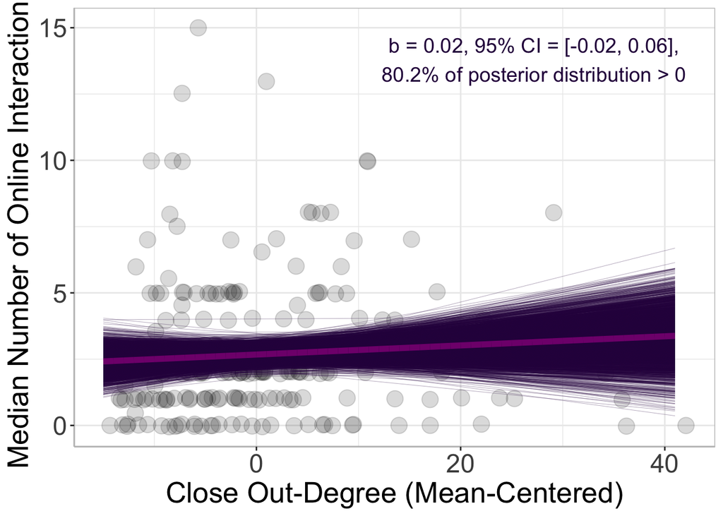

```r
# Extract all posterior distributions
p <- posterior_samples(fb)[, c(1:2)]
colnames(p) <- c("intercept", "baseline_closest_deg_out_norm_c")
p <- p %>%
  dplyr::mutate(draw = 1:4000,
                m_int = median(intercept), # Extract fixed effects medians from the model
                m_b_close_deg_out = median(baseline_closest_deg_out_norm_c))

# Define number of posterior draws
nr_random_draws <- 4000

# Add predicted y values for the random draws and fixed effects
p2 <- p[rep(seq_len(nrow(p)), each = 57), ] %>%
  mutate(seq = rep(-15:41, nr_random_draws)) %>%
  rowwise() %>%
  dplyr::mutate(y_draw = intercept + baseline_closest_deg_out_norm_c * seq,
                y_fe = m_int + m_b_close_deg_out * seq)

## Plot results
ggplot(data = df, aes(baseline_closest_deg_out_norm_c, median_SocInt_NUM)) +
  geom_jitter(alpha = .15, width = 3, height = .05, size = 5) +
  theme_bw() +
  theme(axis.text=element_text(size=18),
        axis.title=element_text(size=20),
        axis.line = element_line(colour = "gray"),
        panel.border = element_rect(colour = "gray"),
        strip.text = element_text(size=16)) +
  labs(y = "Median Number of Online Interactions",
       x = "Close Out-Degree (Mean-Centered)", color = "C") +
  geom_line(data = p2, aes(x = seq, y= y_draw,
                                    group = draw),
                     color = "#2D004B",
                     alpha = .6, linewidth = .1) +
  geom_line(data = p2, aes(x = seq, y = y_fe),
            color = "#810F7C", linewidth = 2) +
  annotate(geom="text", x=27.2, y=13.8, size = 5,
           label="b = 0.02, 95% CI = [-0.02, 0.06],\n80.2% of posterior distribution > 0",
           color="#2D004B")
```

```r
ggsave(file=sprintf("%s/Figures/2.a. Nr-Online_Interactions_Out-Degree.pdf", path),
       units="in", width=8, height=6, dpi=300)
```